# Names

- Alison Camille Dunning
- Amogh Patankar
- Matthieu Dante Pardin
- Zhenyi Chen

# Research Question

Which neighborhoods in the City of Detroit had the most crime in 2011-2014? Can we attribute relative crime rates to factors such as the presence of storm prevention infrastructure, government protection, or policing? Do any of these factors contribute to a certain *kind* of crime?

# Hypothesis

We believe that relative crime rates across neighborhoods in Detroit can be attributed to said factors, specifically, policing and stormwater prevention infrastructure. Some of these factors will also correlate to the rates of specific types of crimes.

# Data Cleaning

- Splitting in location columns into latitude and longitude values
- Removed or adjusted missing values and outliers
- Standardized neighborhood names
- Merged all data on `neighborhood`
- To avoid imbalanced binary variables, transformed columns based on quantile, specifically for `patrolled`

## Master Dataset

After merging all the datasets, we have a master dataset with crime information and binary values for whether a neighborhood has storm drains, is patrolled, or is a Master Plan neighborhood.

# Data Analysis & Results

## Plotting Crime Categories in Highly Represented Neigborhoods

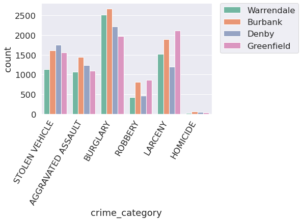

```python
chart_byCategory = sns.countplot(x = 'crime_category', hue='neighborhood', palette="Set2", data = crime_represent)
chart_byCategory.set_xticklabels(chart_byCategory.get_xticklabels(), rotation=60, horizontalalignment='right')
plt.legend(bbox_to_anchor=(1.05, 1), loc=2, borderaxespad=0.)
```

## Calculating Crime Rates

We need a variable that will serve to quantify the amount of crime for each neighborhood in our dataset. Before doing this, we need to stress that there are reliability implications that come with this technique. We note this in the **Ethics and Privacy** section of this project. Our method for quantifying crime will use the counts of each neighborhood in this dataset per year. Note that even though this is a count quantity, we will be referring to it as a crime "rate" hereafter for simplicity.

However, since we are given crime categories, we can predict larceny rates, assault rates, etc., in a neighborhood per year, as a percentage of its total crimes. We hypothesize that this may give interesting results.

## Hypothesis Tests on Crime Rates, Trends, and Categories

Given the visualizations and information above, we will conduct hypothesis tests on the following outcome variables:

1. Crime rates (counts)
2. Sharp increases or decreases in crime from 2011 to 2014
3. Distributions of each crime category

These will be based on the following explanatory variables:

1. Patrolled vs. non-patrolled
2. Heavily patrolled vs. non-heavily patrolled
3. Presence of storm infrastructure
4. Master Plan neighborhoods vs. non-Master Plan neighborhoods

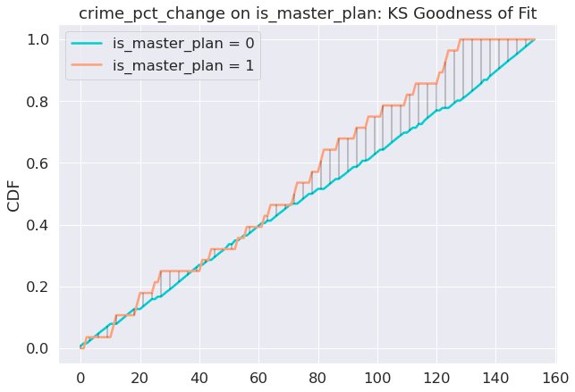

```python
plot_ks_2samp(unique_nb_pct_no_outliers, 'is_master_plan', 'crime_pct_change')
```

# Ethics & Privacy

The datasets in use for this specific project are retrieved from open data portals, provided by the city of Detroit and Ferndale (both in Michigan). The datasets are publicly available, with no licenses required to access them. Hence, we are able to use the datasets for their own analysis for this project.

The City of Detroit Open Data Portal, and the City of Ferndale Open Data Portal both are a type of open government dataset. Due to their .gov website extension, they are being monitored by the Cybersecurity and Infrastructure Security Agency (CISA), which is a US federal government agency. Due to these reasons, our belief is that both websites provide us with datasets that do not contain fabricated data, and that they are secure to use data from.

Considering the credibility of both **government** websites, we believe that the data being used in this project is accurate and satisfactory to work with. The variables we use and perform analysis upon are without any form of identification, meaning they do not contain any specificity with respect to individual privacy.

Even if the data that we are using are ethical, we can't rule out possible biases. An example of such biases include the location data used in our analysis. We understand that measuring these variables with the utmost accuracy and precision is not feasible, and contains room for human error. However, because that particular data (latitude, longitude) has such microscopic error, we do not necessarily account for an error of this type. That being said, our goals for this project are to conduct a thorough, objective analysis with ethics and privacy accounted for from as many angles possible.

# Conclusion and Discussion

- From 2011 to 2014, Burbank is the neighborhoods in the city of Detroit with the most crime.
- Crime rates are higher when the neighborhood is **highly patrolled** and is part of Detroit's Master Plan.
- Having a Master Plan is predominant factor affecting all six kinds of crime.